# A simple social distancing model

Caroline Colijn

14/03/2020

## A building block model without distancing

A very simple model could have 6 compartments: susceptible (S), exposed but not infectious (E1), exposed and infectious but not symptomatic (E2), infectious (I), self-isolated (Q) and recovered (R). This could be called an S E1 E2 I Q R model. Pre-symptomatic transmission occurs in the model (E2 contribute to the force of infection). There is no social distancing yet but this model is the main building block for a very simple social distancing model.

```r
seiqrmodel <- function(t,state,pars) {
  with(as.list(c(state,pars)), {
    dSdt = -(R0/(D+1/k2))*(I+E2)*S/N
    dE1dt = (R0/(D+1/k2))*(I+E2)*S/N - k1*E1
    dE2dt = k1*E1 -k2*E2
    dIdt = k2*E2 - q*I-  I/D
    dQdt = q*I - Q/D
    # dRdt = I/D; dr + ds + di =0, S+I+R = N --> R = N-S-I and we eliminate R
     list(c(dSdt,dE1dt, dE2dt, dIdt, dQdt ))
  })
}
```

Here is one simulation showing the epidemic curve for this model with some baseline parameters that reflect very little intervention.

```r
N=2.4e6
i0=50
state=c(S=N-i0, E1=0, E2=0, I=i0, Q=0)
times = seq(0,200, by=0.1)
pars=list(N=N,D=5,R0=2.56,k1=1/4, k2=1,q=0 )
out = as.data.frame(ode(y= state, times=times,  func=seiqrmodel, parms=pars))
```

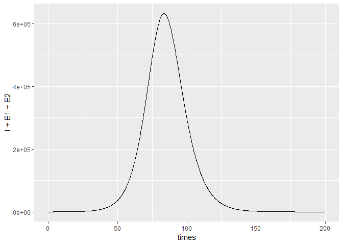

```r
ggplot(data=out, aes(x=times,y=I+E1+E2))+geom_line()
```

## Social distancing : MODEL DEFINITION

Here, there are two “copies” of the S E1 E2 I Q R model. One is as normal and the other has social distancing. People move in and out of the social distancing groups. Social distancing reduces the frequency of contact.

This model does not have asymptomatic individuals (who never show symptoms but who transmit anyway).

It makes a number of simplifying assumptions. For example, those who quarantine are quarantined perfectly, but quarantine happens at a low rate to capture the fact that not everyone will know they have symptoms right away, not everyone will self-isolate, and self-isolation may be imperfect.

In social distancing, all contacts are reduced by a fraction $f$ for all those engaging in social distancing, and so on. This simple model agrees well with more complex models that consider different kinds of contacts (home, work, school, community) with opposing effects under different kinds of social distancing measures. For example, with schools closed, household contact rates may have a slight rise; some community contacts remain even if people work remotely. This model assumes homogeneous mixing in the population, which despite the complexity of human communities, has been shown to do a surprisingly good job of reflecting the dynamics of respiratory viruses.

The equations are
$$\frac{dS}{dt} = -\left(\frac{R_0}{D+\tfrac{1}{k_2}}\right) (I+E_2 + f (I_d+E_{2d}))\frac{S}{N} - rS + u_r S_d$$
$$\frac{dE_1}{dt} = \left(\frac{R_0}{D+\tfrac{1}{k_2}}\right) (I+E_2 + f (I_d+E_{2d}))\frac{S}{N} - r E_1 + u_r E_{1d}$$
$$\frac{dE_2}{dt} = k_1 E_1 - k_2 E_2 -r E_2 + u_r E_{2d}$$

$$\frac{dI}{dt} = k_2 E_2 - qI-I/D-rI + u_r I_d$$

$$\frac{dQ}{dt} = q I -Q/D - rQ+u_r Q_d$$

$$\frac{dR}{dt} = I/D + Q/D - rR + u_r R_d$$

There are 6 more equations just like these for the subscript $d$ compartments; these are socially distancing. They contribute a reduced amount (by a factor $f$) to the force of infection and they ALSO have a reduced contact rate. So for example

$$\frac{dS_d}{dt} = -\left(f\frac{R_0}{D+\tfrac{1}{k_2}}\right) (I+E_2 + f (I_d+E_{2d}))\frac{S_d}{N} + rS - u_r S_d$$
and so on – as above, but with the signs reversed for the $r$ and $u_r$ terms. In this model, a fraction $r/(u+r)$ of the population is engaging in social distancing.

```r
socdistmodel <- function(t,state,pars,sdtiming) {
  with(as.list(c(state,pars)), {
    f = ifelse(sdtiming(t)==1, pars$f, 1) # if social distancing is on, use pars$f. Otherwise, f is 1.
    dSdt = -(R0/(D+1/k2))*(I+E2 + f*(Id+E2d))*S/N - r*S + ur*Sd
    dE1dt = (R0/(D+1/k2))*(I+E2 + f*(Id+E2d))*S/N - k1*E1 -r*E1 + ur*E1d
    dE2dt = k1*E1 -k2*E2 -r*E2 + ur*E2d
    dIdt = k2*E2 - q*I -  I/D - r*I+ ur*Id
    dQdt = q*I - Q/D -r*Q + ur*Qd
    dRdt = I/D + Q/D -r*R+ur*Rd

    dSddt = -(f*R0/(D+1/k2))*(I+E2 + f*(Id+E2d))*Sd/N + r*S -ur*Sd
    dE1ddt = (f*R0/(D+1/k2))*(I+E2 + f*(Id+E2d))*Sd/N - k1*E1d +r*E1 - ur*E1d
    dE2ddt = k1*E1d - k2*E2d + r*E2 - ur*E2d
    dIddt = k2*E2d - q*Id-  Id/D + r*I - ur*Id
    dQddt = q*Id - Qd/D +r*Q - ur*Qd
   dRddt = Id/D+Qd/D +r*R - ur*Rd
    # dRdt = I/D; dr + ds + di =0, S+I+R = N --> R = N-S-I and we eliminate R
     list(c(dSdt,dE1dt, dE2dt, dIdt, dQdt,dRdt, dSddt,dE1ddt, dE2ddt, dIddt, dQddt,dRddt ))
  })
}
```

Here are just two simulations. In the black curve, after 60 days, social distancing stops, and the curve grows again.

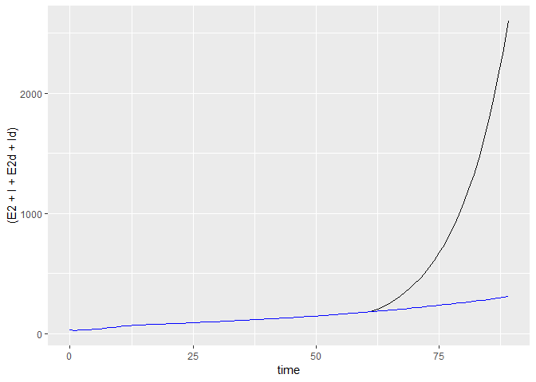

```r
startTime=10; stopTime=60
N=2.4e6
pars=list(N=N,D=5,R0=2.5,k1=1/4, k2=1,q=0.08, r=1, ur=0.8, f=0.6)
mysdtiming=function(t) {ifelse( (t > startTime & t< stopTime),1, 0) }

fsi=with(pars, r/(r+ur))
nsi=1-fsi
state=c(S= nsi*(N-i0), E1=0.4*nsi*i0, E2=0.1*nsi*i0, I=0.5*nsi*i0, Q=0, R=0,
        Sd= fsi*(N-i0), E1d=0.4*fsi*i0, E2d=0.1*fsi*i0, Id=0.5*fsi*i0, Qd=0, Rd=0)

times=0:400
i0=50
nReps=50
out1 = as.data.frame(ode(y= state, times=times,  func=socdistmodel, parms=pars,
          sdtiming=mysdtiming))
stopTime=200; mysdtiming=function(t) {ifelse( (t > startTime & t< stopTime),1, 0) }
out2=  as.data.frame(ode(y= state, times=times,  func=socdistmodel, parms=pars,
          sdtiming=mysdtiming))
ggplot(data=filter(out1,time<90), aes(x=time, y=(E2+I+E2d+Id)))+geom_line() +
  geom_line(data=filter(out2,time<90), aes(x=time, y=(E2+I+E2d+Id)),color="blue")
```

## Model simulation

This code is structured to take a baseline and compare 3 values of the social distancing strength.

```r
N=2.4e6
pars=list(N=N,D=5,R0=2.5,k1=1/4, k2=1,q=0, r=1, ur=0.8, f=0.6)
fsi=with(pars, r/(r+ur))
nsi=1-fsi
state=c(S= nsi*(N-i0), E1=0.4*nsi*i0, E2=0.1*nsi*i0, I=0.5*nsi*i0, Q=0, R=0,
        Sd= fsi*(N-i0), E1d=0.4*fsi*i0, E2d=0.1*fsi*i0, Id=0.5*fsi*i0, Qd=0, Rd=0)

times=0:400
i0=50
nReps=50
```

```r
# set up 3 sets of parameters to explore no, medium and strong social distancing
bpars=list(); timelist=list()
bpars[[1]]=pars; bpars[[1]]$f=1
timelist[[1]]=function(t) {ifelse( (t > 5 & t< 1000),1, 0) }
bpars[[2]]=pars; bpars[[2]]$f=0.8
timelist[[2]]=function(t) {ifelse( (t > 5 & t< 1000),1, 0) }
bpars[[3]]=pars; bpars[[3]]$f=0.6
timelist[[3]]=function(t) {ifelse( (t > 5 & t< 1000),1, 0) }
# set up timing information: when do we stop and start social distancing?

tt2=lapply(1:3,function(x) multisolve(params=bpars[[x]],timing = timelist[[x]], state,times, nReps = nReps))
names(tt2)=c(bpars[[1]]$f, bpars[[2]]$f,bpars[[3]]$f)
```

Extract cases by day for plots (and spreadsheets if required)

```r
cbd1 = getCasesbyDay2(tt2[[1]], times,nReps)
cbd2 = getCasesbyDay2(tt2[[2]], times,nReps)
cbd3 = getCasesbyDay2(tt2[[3]], times,nReps)
```

## Step 1: the baseline curve with no measures taken

Here is the first of these three simulations.

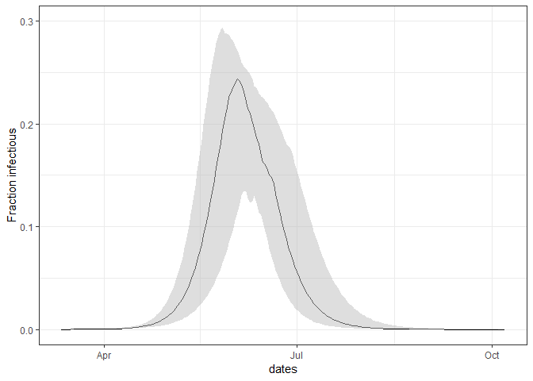

```r
N=bpars[[1]]$N
mydf=filter(getAllCasesbyDay2(tt2[[1]],times,nReps), times<210)
ggplot(data=mydf) + geom_line(aes(x=dates,y=median/N))+
  geom_ribbon(aes(x=dates,ymin = lower25/N, ymax = upper75/N), alpha = 0.5,fill="grey") +
  theme_bw()+ylab("Fraction infectious")+ylim(c(0,0.3))
```

Here is a plot showing the cumulative number who have been infected (this now includes those who are still in the incubation period)

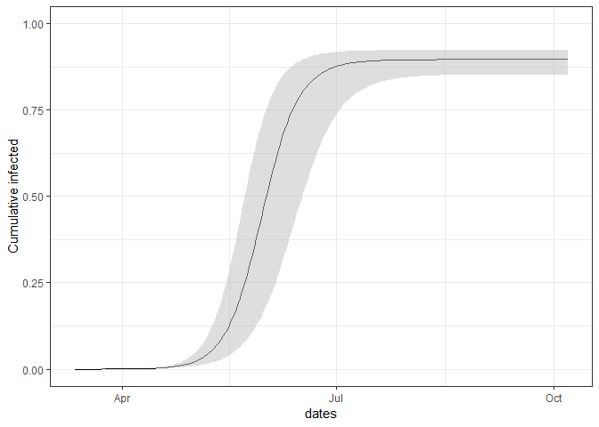

```r
N=bpars[[1]]$N
mydf=filter(getEverInfbyDay(tt2[[1]],times,nReps), times<210)
ggplot(data=mydf) + geom_line(aes(x=dates,y=median/N))+
  geom_ribbon(aes(x=dates,ymin = lower25/N, ymax = upper75/N), alpha = 0.5,fill="grey") +
  theme_bw()+ylab("Cumulative infected")+ylim(c(0,1))
```

## Step 2

```r
hh=0.25; school=0.25*0.4; work=0.75*0.4; community=0.35; # portion contacts
f = hh*1 + school*0.9 + work*0.65 + community*0.75
f
```

```
## [1] 0.7975
```

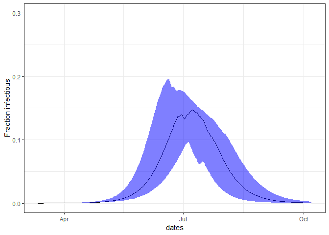

```r
N=bpars[[2]]$N
mydf=filter(getAllCasesbyDay2(tt2[[2]],times,nReps), times<210)
ggplot(data=mydf) + geom_line(aes(x=dates,y=median/N))+
  geom_ribbon(aes(x=dates,ymin = lower25/N, ymax = upper75/N), alpha = 0.5,fill="blue") +
  theme_bw()+ylab("Fraction infectious")+ylim(c(0,0.3))
```

Here are the cumulative numbers infected.

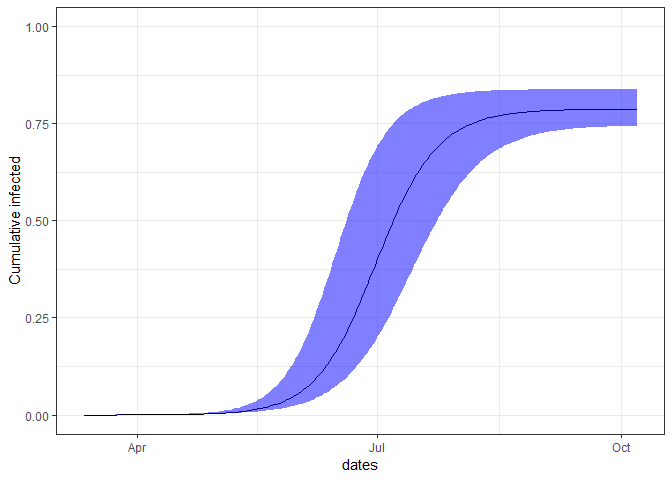

```r
N=bpars[[1]]$N
mydf=filter(getEverInfbyDay(tt2[[2]],times,nReps), times<210)
ggplot(data=mydf) + geom_line(aes(x=dates,y=median/N))+
  geom_ribbon(aes(x=dates,ymin = lower25/N, ymax = upper75/N), alpha = 0.5,fill="blue") +
  theme_bw()+ylab("Cumulative infected")+ylim(c(0,1))
```

## Step 3: Strong broad social distancing interventions

```r
hh=0.25; school=0.25*0.4; work=0.75*0.4; community=0.35; # portion contacts
f = hh*1.45 + school*0.1 + work*0.35 + community*0.35
f
```

```
## [1] 0.6
```

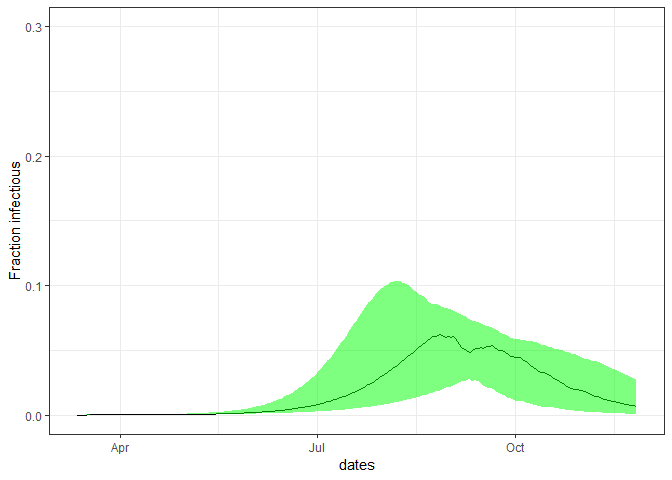

```r
N=bpars[[3]]$N # actually resetting N isn't necessary, but it's good practice
mydf=filter(getAllCasesbyDay2(tt2[[3]],times,nReps), times<260)
ggplot(data=mydf) + geom_line(aes(x=dates,y=median/N))+
  geom_ribbon(aes(x=dates,ymin = lower25/N, ymax = upper75/N), alpha = 0.5,fill="green") +
  theme_bw()+ylab("Fraction infectious")+ylim(c(0,0.3))
```

And cumulative infected:

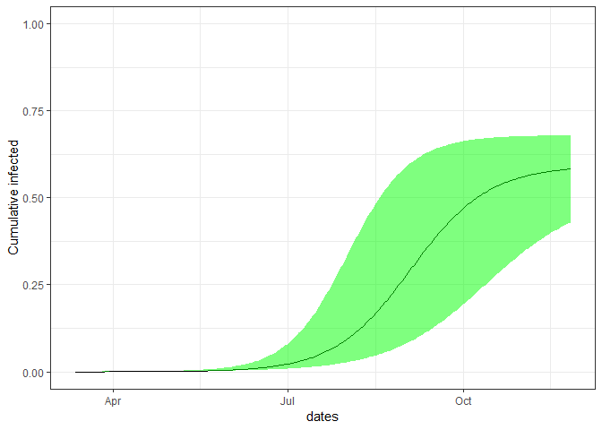

```r
N=bpars[[1]]$N
mydf=filter(getEverInfbyDay(tt2[[3]],times,nReps), times<260)
ggplot(data=mydf) + geom_line(aes(x=dates,y=median/N))+
  geom_ribbon(aes(x=dates,ymin = lower25/N, ymax = upper75/N), alpha = 0.5,fill="green") +
  theme_bw()+ylab("Cumulative infected")+ylim(c(0,1))
```

## Comparisons and the early phase

Here we show three social distancing scenarios on the same plot for comparison, and we show the early rise. In most of the above plots, it looks like there are no cases in the first few months, but this is misleading. It’s not that there are no cases, it’s just that the numbers grow so high later that we can’t see the rises in the early phase unless we zoom in on that time period.

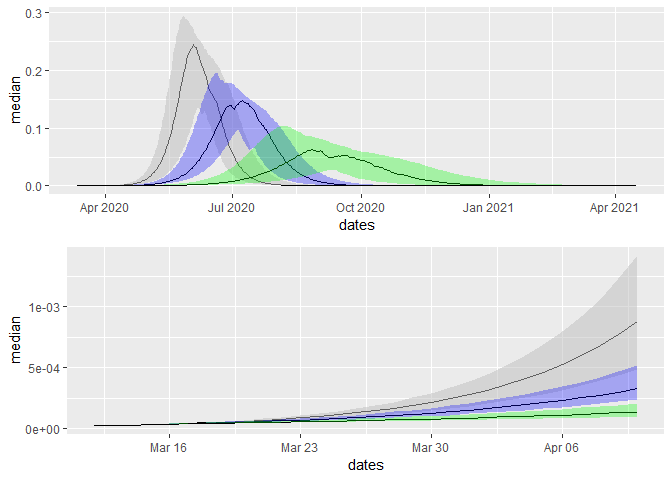

```r
ll=makePlots(tt2,type="all",PopScale = TRUE,popSize =pars$N)
grid.arrange(ll[[1]], ll[[2]])
```

## Step 4 what happens if social distancing is turned off at a fixed time?

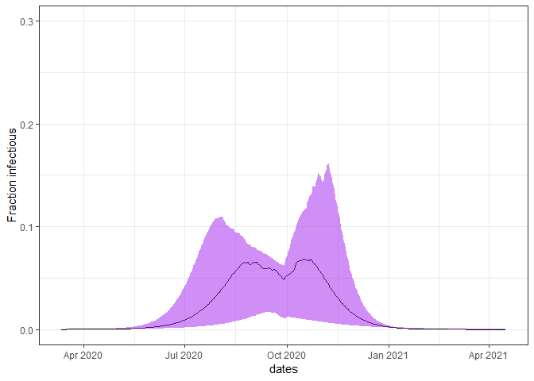

```r
newtime=function(t) {ifelse( (t > 5 & t< 200),1, 0) }
newsol= multisolve(params=bpars[[3]],timing = newtime, state,times, nReps = nReps)
mydf=getAllCasesbyDay2(newsol,times,nReps)
ggplot(data=mydf) + geom_line(aes(x=dates,y=median/N))+
  geom_ribbon(aes(x=dates,ymin = lower25/N, ymax = upper75/N), alpha = 0.5,fill="purple") +
  theme_bw()+ylab("Fraction infectious")+ylim(c(0,0.3))
```

What if it is turned off at 100 days instead? (dark green fill, below).

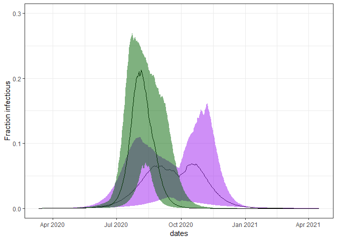

```r
new2=function(t) {ifelse( (t > 5 & t< 100),1, 0) }
new2sol= multisolve(params=bpars[[3]],timing = new2, state,times, nReps = nReps)
mydf2=getAllCasesbyDay2(new2sol,times,nReps)
ggplot(data=mydf) + geom_line(aes(x=dates,y=median/N))+
  geom_ribbon(aes(x=dates,ymin = lower25/N, ymax = upper75/N), alpha = 0.5,fill="purple") +
  geom_line(data=mydf2, aes(x=dates,y=median/N))+
  geom_ribbon(data=mydf2,aes(x=dates,ymin=lower25/N, ymax = upper75/N), alpha = 0.5,fill="darkgreen")+
  theme_bw()+ylab("Fraction infectious")+ylim(c(0,0.3))
```

## Step 5: “Planking” the curve

Here we explore the “planking” idea – social distancing that is strong enough that we are likely to stop exponential growth in its tracks.

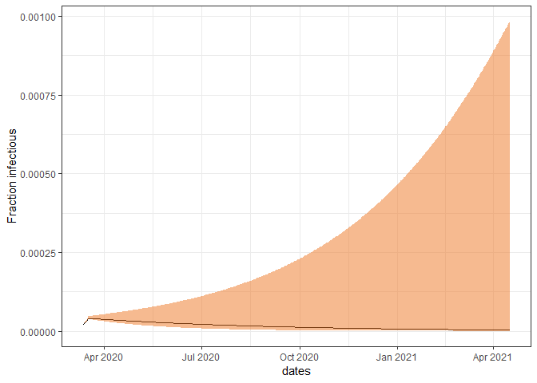

```r
newtime=function(t) {ifelse( (t > 5 & t< 400),1, 0) }
strongpars = list(N=N,D=5,R0=2.5,k1=1/4, k2=1,q=0, r=1, ur=0.4, f=0.46)
# imports = rpois(length(times), lambda = 1.5)
newsol= multisolve(params=strongpars,timing = newtime, state,times, nReps = nReps)
mydf=getAllCasesbyDay2(newsol,times,nReps)
ggplot(data=mydf) + geom_line(aes(x=dates,y=(median)/N))+
  geom_ribbon(aes(x=dates,ymin = (lower25+qpois(0.25,2))/N, ymax = (upper75+qpois(0.75,2))/N), alpha = 0.5,fill="chocolate2") +
  theme_bw()+ylab("Fraction infectious") #+ylim(c(0,0.3))
```

### Step 5b Better than planking: suppression

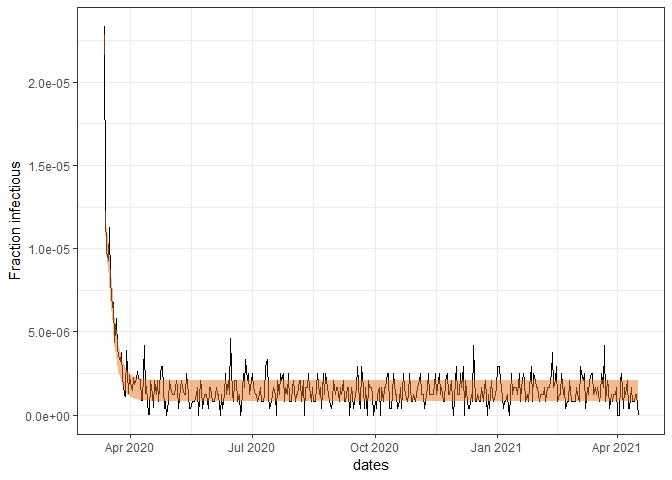

```r
newtime=function(t) {ifelse( (t > 5 & t< 400),1, 0) }
strongpars = list(N=N,D=5,R0=2.5,k1=1/4, k2=1,q=008, r=1, ur=0.4, f=0.38)
imports = rpois(length(times), lambda = 3.5)
newsol= multisolve(params=strongpars,timing = newtime, state,times, nReps = nReps)
mydf=getAllCasesbyDay2(newsol,times,nReps)
ggplot(data=mydf) + geom_line(aes(x=dates,y=(median+imports)/N))+
  geom_ribbon(aes(x=dates,ymin = (lower25+qpois(0.25,3.5))/N, ymax = (upper75+qpois(0.75,3.5))/N), alpha = 0.5,fill="chocolate2") +
  theme_bw()+ylab("Fraction infectious") #+ylim(c(0,0.3))
```

And now what happens if the curve falls, people get complacent, and measures are relaxed?

```r
newtime=function(t) {ifelse( (t > 5 & t< 60) ,1, 0) }
strongpars = list(N=N,D=5,R0=2.5,k1=1/4, k2=1,q=0, r=1, ur=0.4, f=0.38)
imports = rpois(length(times), lambda = 1.5)
newsol= multisolve(params=strongpars,timing = newtime, state,times, nReps = nReps)
```

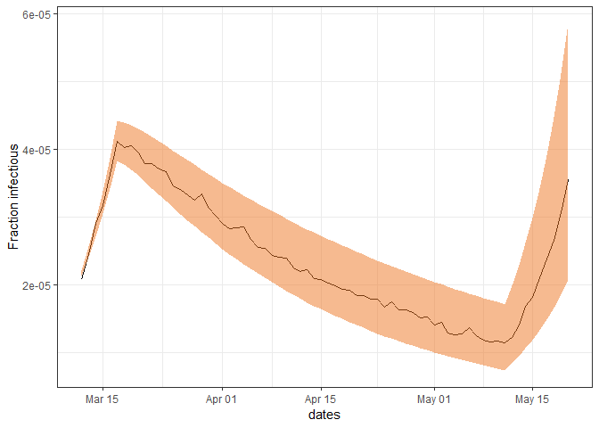

```r
mydf=getAllCasesbyDay2(newsol,times,nReps)
ggplot(data=filter(mydf, times<70)) + geom_line(aes(x=dates,y=(median+imports[1:70])/N))+
  geom_ribbon(aes(x=dates,ymin = (lower25+qpois(0.25,2))/N, ymax = (upper75+qpois(0.75,2))/N), alpha = 0.5,fill="chocolate2") +
  theme_bw()+ylab("Fraction infectious") #+ylim(c(0,0.3))
```

## Step 5c introduction of social distancing is slower

Here, social distancing takes place over a week with a linear decline in f.

```r
socdist2 <- function(t,state,pars,sdprofile) {
  with(as.list(c(state,pars)), {
#    f = ifelse(sdtiming(t)==1, pars$f, 1) # if social distancing is on, use pars$f. Otherwise, f is 1.
    f=sdprofile(t)
    dSdt = -(R0/(D+1/k2))*(I+E2 + f*(Id+E2d))*S/N - r*S + ur*Sd
    dE1dt = (R0/(D+1/k2))*(I+E2 + f*(Id+E2d))*S/N - k1*E1 -r*E1 + ur*E1d
    dE2dt = k1*E1 -k2*E2 -r*E2 + ur*E2d
    dIdt = k2*E2 - q*I -  I/D - r*I+ ur*Id
    dQdt = q*I - Q/D -r*Q + ur*Qd
    dRdt = I/D + Q/D -r*R+ur*Rd

    dSddt = -(f*R0/(D+1/k2))*(I+E2 + f*(Id+E2d))*Sd/N + r*S -ur*Sd
    dE1ddt = (f*R0/(D+1/k2))*(I+E2 + f*(Id+E2d))*Sd/N - k1*E1d +r*E1 - ur*E1d
    dE2ddt = k1*E1d - k2*E2d + r*E2 - ur*E2d
    dIddt = k2*E2d - q*Id-  Id/D + r*I - ur*Id
    dQddt = q*Id - Qd/D +r*Q - ur*Qd
   dRddt = Id/D+Qd/D +r*R - ur*Rd
    # dRdt = I/D; dr + ds + di =0, S+I+R = N --> R = N-S-I and we eliminate R
     list(c(dSdt,dE1dt, dE2dt, dIdt, dQdt,dRdt, dSddt,dE1ddt, dE2ddt, dIddt, dQddt,dRddt ))
  })
}
```

```r
multisolve2=function(params,timing,state,times,nReps) {
 # get random samples of R0

  rs=rnorm(nReps, mean = params$R0, sd=0.2)
  biglist=lapply(rs, function(x) {
    thispars=params; thispars$R0=x;
    return( as.data.frame(ode(y= state, times=times,  func=socdist2, parms=thispars,sdprofile=timing)))})
  names(biglist)=rs;
  return(bind_rows(biglist, .id="R0"))
}
```

```r
# now I just want f(t) as my timing function

strongpars = list(N=N,D=5,R0=2.5,k1=1/4, k2=1,q=0.08, r=1, ur=0.5, f=0.4)

newtime=function(t) {
  if (t < 15) return(1)
  if (t >=15 & t < 22) return( 1 - (1/7)*(1-0.4)*(t-15) )
  if (t>=22 & t < 60) return(0.4)
  if (t>=60) return(1)
  }

fsi=with(strongpars, r/(r+ur))
nsi=1-fsi
state=c(S= nsi*(N-i0), E1=0.4*nsi*i0, E2=0.1*nsi*i0, I=0.5*nsi*i0, Q=0, R=0,
        Sd= fsi*(N-i0), E1d=0.4*fsi*i0, E2d=0.1*fsi*i0, Id=0.5*fsi*i0, Qd=0, Rd=0)


times=0:80
i0=50
nReps=50

tmp = as.data.frame(ode(y= state, times=times,  func=socdist2, parms=strongpars,sdprofile=newtime))
imports = rpois(length(times), lambda = 1.5)

newsol= multisolve2(params=strongpars,timing = newtime, state,times, nReps = nReps)
```

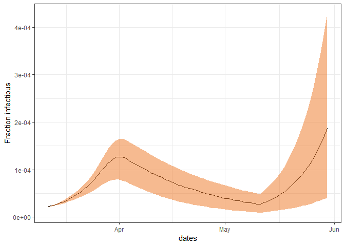

```r
mydf=getAllCasesbyDay2(newsol,times,nReps)
ggplot(data=filter(mydf, times<80)) + geom_line(aes(x=dates,y=(median+imports[1:80])/N))+
  geom_ribbon(aes(x=dates,ymin = (lower25+qpois(0.25,2))/N, ymax = (upper75+qpois(0.75,2))/N), alpha = 0.5,fill="chocolate2") +
  theme_bw()+ylab("Fraction infectious") #+ylim(c(0,0.3))
```

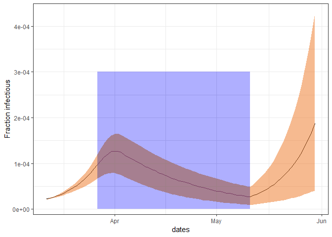

```r
mydf=getAllCasesbyDay2(newsol,times,nReps)
ggplot(data=filter(mydf, times<80)) + geom_line(aes(x=dates,y=(median+imports[1:80])/N))+
  geom_ribbon(aes(x=dates,ymin = (lower25+qpois(0.25,2))/N, ymax = (upper75+qpois(0.75,2))/N), alpha = 0.5,fill="chocolate2") +
geom_rect(aes(xmin=lubridate::ymd("2020-03-12")+15,
                xmax=lubridate::ymd("2020-03-12")+60),
                  ymin=0, ymax=3e-4,
            fill='blue', alpha=.005)  +
  theme_bw()+ylab("Fraction infectious")
```

ANd now one where SD is not turned off

```r
# now I just want f(t) as my timing function

strongpars = list(N=N,D=5,R0=2.5,k1=1/4, k2=1,q=0.08, r=1, ur=0.5, f=0.4)

newtime=function(t) {
  if (t < 15) return(1)
  if (t >=15 & t < 22) return( 1 - (1/7)*(1-0.4)*(t-15) )
  if (t>=22 & t < 60) return(0.4)
  if (t>=60) return(0.4)
  }

fsi=with(strongpars, r/(r+ur))
nsi=1-fsi
state=c(S= nsi*(N-i0), E1=0.4*nsi*i0, E2=0.1*nsi*i0, I=0.5*nsi*i0, Q=0, R=0,
        Sd= fsi*(N-i0), E1d=0.4*fsi*i0, E2d=0.1*fsi*i0, Id=0.5*fsi*i0, Qd=0, Rd=0)


times=0:80
i0=50
nReps=50

tmp = as.data.frame(ode(y= state, times=times,  func=socdist2, parms=strongpars,sdprofile=newtime))
imports = rpois(length(times), lambda = 1.5)

newsol= multisolve2(params=strongpars,timing = newtime, state,times, nReps = nReps)
```

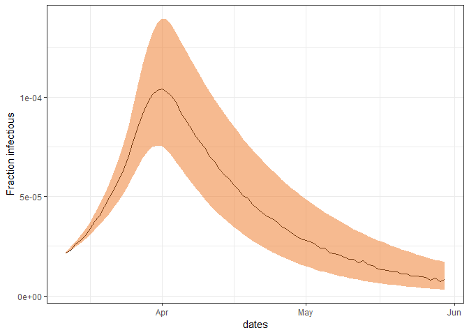

```r
mydf=getAllCasesbyDay2(newsol,times,nReps)
ggplot(data=filter(mydf, times<80)) + geom_line(aes(x=dates,y=(median+imports[1:80])/N))+
  geom_ribbon(aes(x=dates,ymin = (lower25+qpois(0.25,2))/N, ymax = (upper75+qpois(0.75,2))/N), alpha = 0.5,fill="chocolate2") +
  theme_bw()+ylab("Fraction infectious") #+ylim(c(0,0.3))
```

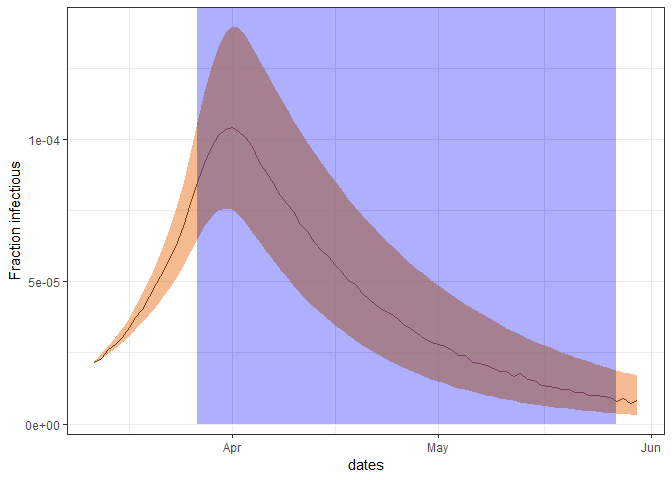

```r
mydf=getAllCasesbyDay2(newsol,times,nReps)
ggplot(data=filter(mydf, times<80)) + geom_line(aes(x=dates,y=(median+imports[1:80])/N))+
  geom_ribbon(aes(x=dates,ymin = (lower25+qpois(0.25,2))/N, ymax = (upper75+qpois(0.75,2))/N), alpha = 0.5,fill="chocolate2") +
geom_rect(aes(xmin=lubridate::ymd("2020-03-12")+15,
                xmax=lubridate::ymd("2020-03-12")+76),
                  ymin=0, ymax=3e-4,
            fill='blue', alpha=.005)  +
  theme_bw()+ylab("Fraction infectious")
```

## Step 6: Smaller population and/or effect of unknown infections

Quite severe measures in China and elsewhere, together with contact tracing, door to door follow up and isolation, kept numbers low and some peaks were fast. In models like the ones here, which consider large populations as homogeneously mixing (anyone can potentially contact anyone else), it takes more time for an outbreak peak to rise and fall than it does in a much smaller population. This is because the first 10 or 100 cases are a tiny fraction of a city of millions, but the first 10 cases are a much larger fraction of a population of hundreds. In a tightly controlled population, not only are contacts reduced, but the population connectedness may be disrupted. We could simulate this using a smaller population – the one the virus gets a chance to spread to.

Similarly, if we start the model with many more exposed or infectious individuals than we know about, we will see an earlier peak again because a higher fraction of the population is already infected so the rise happens sooner. This could occur in the current situation if it were the case that many asymptomatic (or weakly symptomatic) individuals have COVID19 and are developing immunity already without being detected.

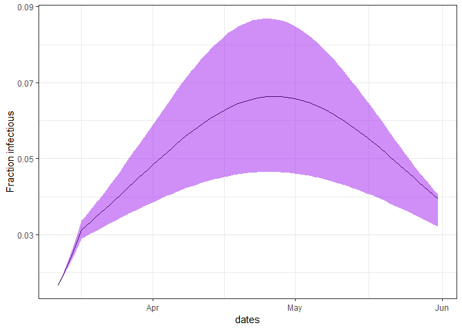

```r
newtime=function(t) {ifelse( (t > 5 & t< 500),1, 0) }
smallN=300
smallpars  = list(N=smallN,D=5,R0=2.5,k1=1/4, k2=1,q=0, r=1, ur=0.4, f=0.64)
i0=5
fsi=with(pars, r/(r+ur))
nsi=1-fsi
smallstate=c(S= nsi*(smallN-i0), E1=0.4*nsi*i0, E2=0.1*nsi*i0, I=0.5*nsi*i0, Q=0, R=0,
        Sd= fsi*(smallN-i0), E1d=0.4*fsi*i0, E2d=0.1*fsi*i0, Id=0.5*fsi*i0, Qd=0, Rd=0)
newsol= multisolve(params=smallpars,timing = newtime, smallstate,times, nReps = nReps)
mydf=getAllCasesbyDay2(newsol,times,nReps)
ggplot(data=mydf) + geom_line(aes(x=dates,y=median/smallN))+
  geom_ribbon(aes(x=dates,ymin = lower25/smallN, ymax = upper75/smallN), alpha = 0.5,fill="purple") +
  theme_bw()+ylab("Fraction infectious")#+ylim(c(0,0.3))
```

Unfortunately, a wider, flatter, curve is just a series of these little bumps, piling on one after the other, and on top of each other. Unless we **really** prevent the small sub-populations having any contact with each other, we are back to the wide, slow curves in models for bigger well-mixed populations. Whether China sees resurgence after normal activities resume will be interesting to see; it would require preventing imported cases.

## Limitations and discussion

There are many limitations here and we cannot discuss them all. There are myriad ways that we could ask “but what about …?” for this kind of modelling: what about individual households? Schools? Workplaces? Transit? Restaurants? Cafes? Playgrounds, nightclubs, bakeries, healthcare settings? Age groups and different mixing patterns? Reducing contacts in some of these while leaving others alone results in an intermediate level of mixing. Reducing contacts in all of them results in strong distancing. In reality, decreasing some may increase others – for example, household and community contacts increasing when people stay home from work or school.

We deliberately did not model these things explicitly. The results agree overall with those who did model some of this complexity (see the Imperial College London report at https://www.imperial.ac.uk/media/imperial-college/medicine/sph/ide/gida-fellowships/Imperial-College-COVID19-NPI-modelling-16-03-2020.pdf

Modelling these requires both assumptions and high-quality data. Unless there is great data, the results of highy sophisticated models may not be better, and in any case may not even be different, than the results of simple models. Simple models are easier to understand, and it is feasible and quick to explore the effects of uncertainty in key parameters like R0 in simple models. The uncertainty in R0 whose effects are illustrated here is considerable. Adding complexity where there is little data to inform the model will not reduce uncertainty, but it will make that uncertainty harder to represent.

We did not explicitly model uncertainty in the durations of the compartments. However, unless the numbers are all wrong in the same direction, the qualitative results here will not be much affected. Furthermore, the overall time scale (a few weeks from infection to recovery) is well established and this sets the peak timing and so on.

Two of the largest remaining uncertainties are (1) the effect that real social distancing is having (and how long we can carry on for), and (2) the role of asymptomatic or weakly symptomatic individuals, particularly if they are numerous and are already gaining immunity. If there are many such people the peaks would be earlier and lower.

This work was the basis for the figures in the article at https://www.theglobeandmail.com/business/technology/science/article-when-does-social-distancing-end-these-graphs-show-where-were-heading/.